# Assignment 1

2024-09-25

## Federica Malamisura

## FA 582-A Foundation of Financial Data Science

## Professor Dragos Bozdog

## Assignment 1

## PROBLEM 1:

Problem 1 involves real estate sales across the five boroughs of New York City. I started by loading the datasets for the Bronx, Brooklyn, Manhattan, Queens, and Staten Island into R.

I loaded the sales data for each borough, standardized the column names, and combined the datasets by adding a column to identify the borough.

I formatted the sale dates, handled missing values by removing columns like ease.ment while retaining useful ones, converted relevant columns to numeric types, and filtered out entries with zero or missing sale prices.

I focused on specific residential building categories, including one-, two-, and three-family homes, coops, and condos, by creating a subset called nyc_residential and added sale.month and sale.year columns for temporal analysis.

## Exploratory Data Analysis (EDA)

## Visualizing Sale Prices

# Histogram of Sale Prices:

Plotted sale prices across different building categories.

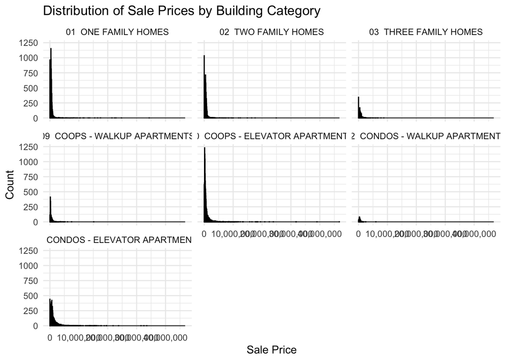

Observation: The distribution was right-skewed, with most properties sold at lower prices and fewer high-priced sales.

# Boxplots by Borough:

Created boxplots to compare sale prices across boroughs.

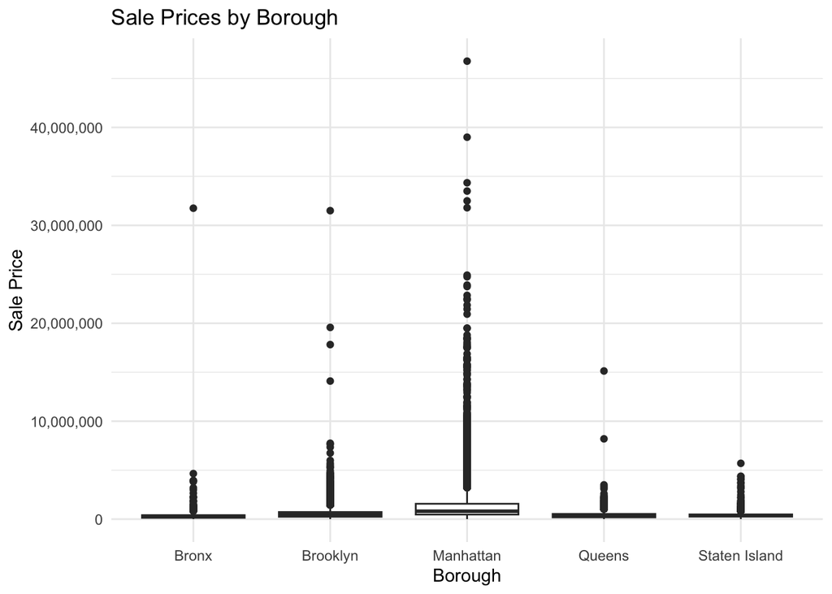

Observation: Manhattan stood out with higher median and mean sale prices, indicating a more expensive real estate market.

## Sale Prices Over Time

# Scatter Plot:

Plotted sale prices over the sale date, color-coded by borough.

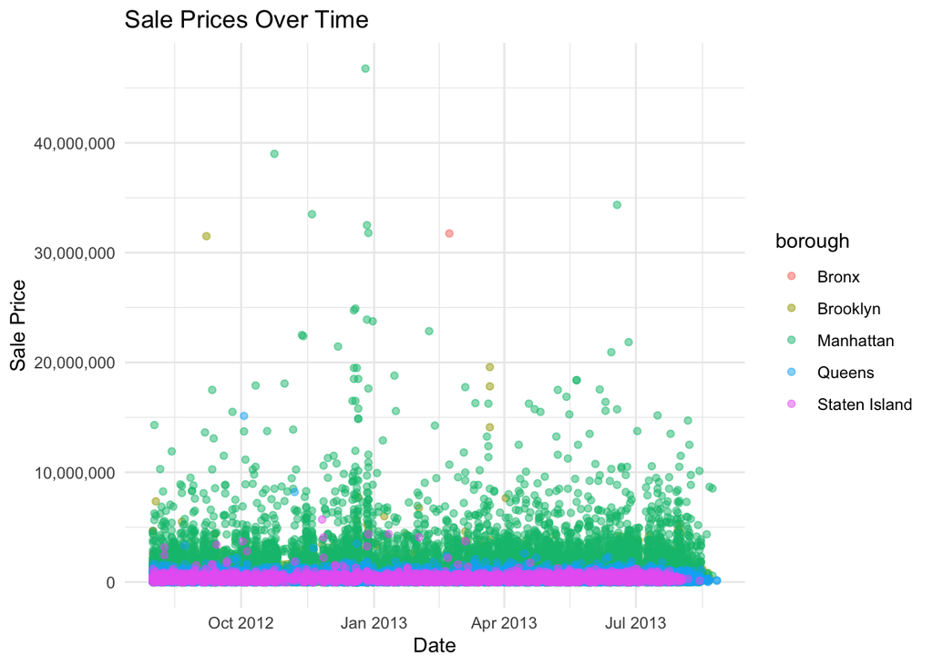

Observation: There wasn’t a distinct trend over time, but Manhattan consistently showed higher sale prices.

## Statistical Summary

I calculated summary statistics grouping by building category and borough:

- Count: Number of sales in each group.
- Mean and Median Sale Price: Average and middle value sale prices.
- Standard Deviation: Variability within each group

```
## # A tibble: 35 × 6
## # Groups:   building.class.category [7]
##    building.class.category borough       count mean_price median_price sd_price
##    <chr>                   <chr>         <int>      <dbl>        <dbl>    <dbl>
##  1 01  ONE FAMILY HOMES    Bronx           644    349355.       330000  344950.
##  2 01  ONE FAMILY HOMES    Brooklyn       1859    577494.       470000  608882.
##  3 01  ONE FAMILY HOMES    Manhattan       128   5155628.      3825000 5770568.
##  4 01  ONE FAMILY HOMES    Queens         4864    429331.       412935  276762.
##  5 01  ONE FAMILY HOMES    Staten Island  2196    396310.       370000  330138.
##  6 02  TWO FAMILY HOMES    Bronx           860    323760.       356000  171046.
##  7 02  TWO FAMILY HOMES    Brooklyn       3503    570944.       491421  526998.
##  8 02  TWO FAMILY HOMES    Manhattan       113   3468860.      1700000 4288770.
##  9 02  TWO FAMILY HOMES    Queens         2951    456161.       460000  282796.
## 10 02  TWO FAMILY HOMES    Staten Island   818    453124.       463000  253632.
## # ℹ 25 more rows
```

## Key Findings:

- Manhattan: Dominated in terms of higher sale prices across all categories. Reflects the premium real estate market in this borough.
- Staten Island and the Bronx: Had lower average sale prices, indicating more affordable housing options.

## Conclusions and Insights

Analyzing the NYC real estate data provided several insights:

- Market Variations: There’s a significant disparity in property values between Manhattan and the outer boroughs.
- Property Types: Single-family homes are more prevalent in Staten Island and Queens, while Manhattan has more coops and condos.
- Investment Opportunities: Investors might find lucrative opportunities in Manhattan for high-end properties.
- Affordable housing projects could focus on the Bronx and Staten Island.

## PROBLEM 2:

Problem 2 involves simulated advertising data from the New York Times homepage over three days. The datasets (nyt1.csv, nyt2.csv, nyt3.csv) represent user interactions with ads, including age, gender, ad impressions, clicks, and login status for each user.

I’ve prepared the data by creating age groups for demographic analysis, to allow for grouping and comparing user behavior across different life stages.

I’ve converted numerical codes like gender and login status to descriptive labels, calculated click-through rates, and segmented users based on click behavior to analyze engagement patterns.

## Exploratory Data Analysis

## Comparing User Segments

# <20-Year-Old Males vs. Females

# Impressions

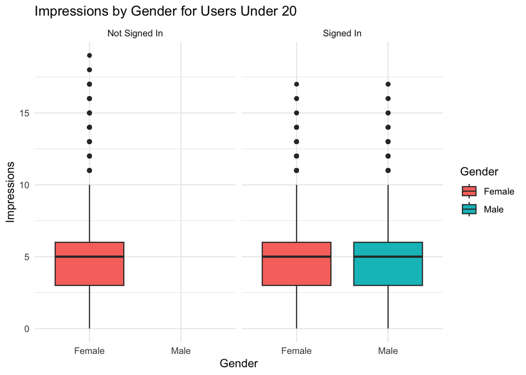

# CTR

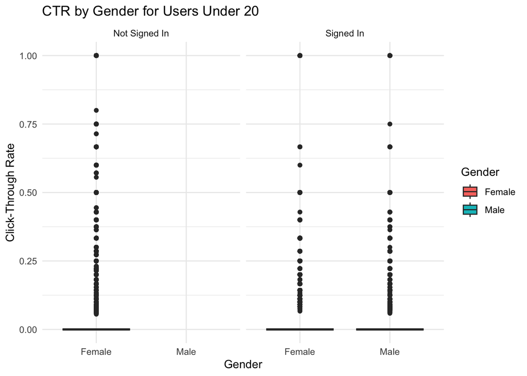

Observation: Males under 20 had a marginally higher CTR than females.

## Statistical Summary

```
## # A tibble: 3 × 6
## # Groups:   Gender [2]
##   Gender Signed_In     Mean_Impressions Median_Impressions Mean_CTR Median_CTR
##   <fct>  <fct>                    <dbl>              <dbl>    <dbl>      <dbl>
## 1 Female Not Signed In             5.00                  5   0.0281          0
## 2 Female Signed In                 5.02                  5   0.0209          0
## 3 Male   Signed In                 4.99                  5   0.0233          0
```

# Impressions and CTR Across Age Groups:

# Impressions

Explored how many ads users in different age groups were shown.

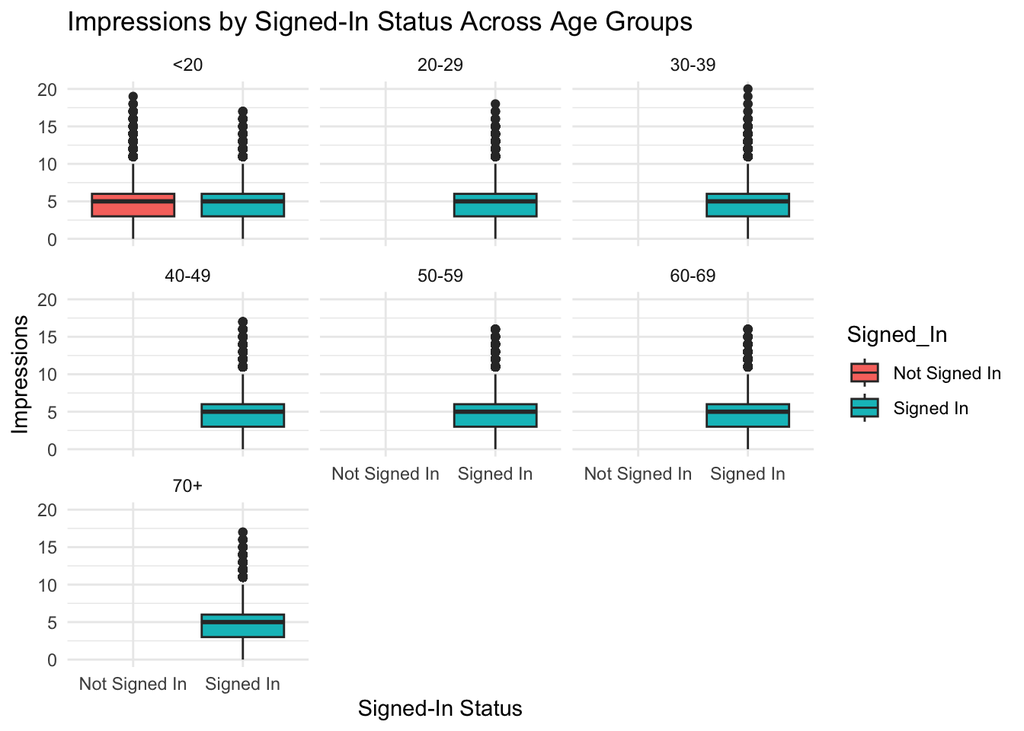

# CTR

Analyzed the propensity of different age groups to click on ads.

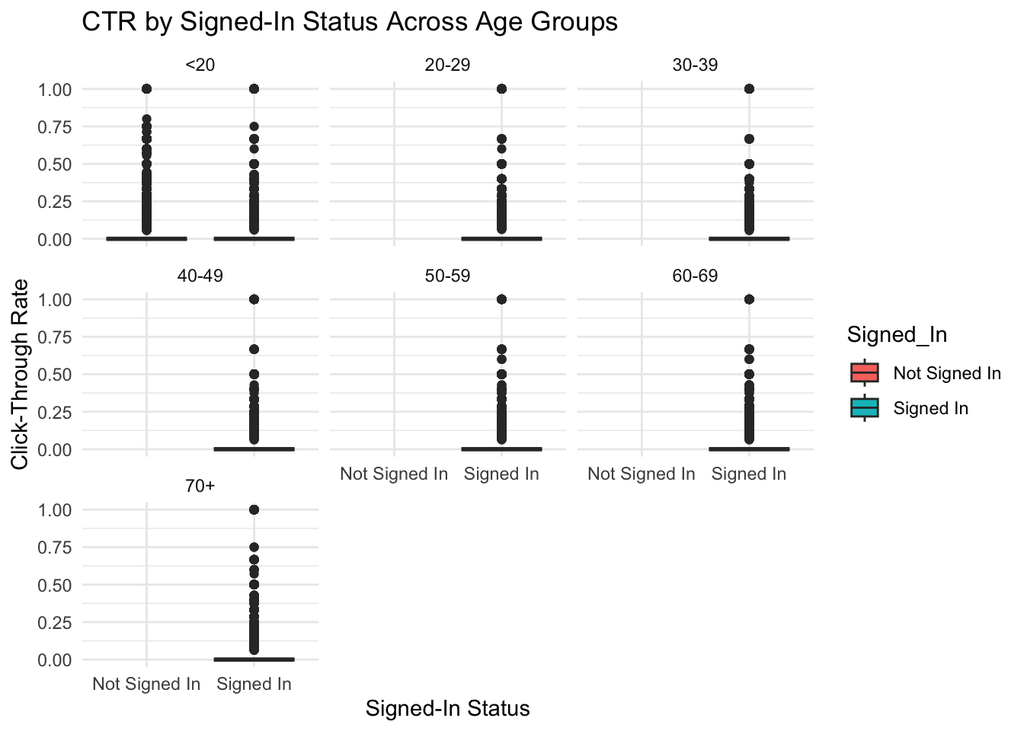

## Statistical Summary

```
## # A tibble: 8 × 6
## # Groups:   Signed_In [2]
##   Signed_In    age_group Mean_Impressions Median_Impressions Mean_CTR Median_CTR
##   <fct>        <fct>                <dbl>              <dbl>    <dbl>      <dbl>
## 1 Not Signed … <20                   5.00                  5  0.0281           0
## 2 Signed In    <20                   5.00                  5  0.0224           0
## 3 Signed In    20-29                 4.99                  5  0.00996          0
## 4 Signed In    30-39                 5.00                  5  0.0101           0
## 5 Signed In    40-49                 5.00                  5  0.0101           0
## 6 Signed In    50-59                 5.01                  5  0.0142           0
## 7 Signed In    60-69                 5.01                  5  0.0231           0
## 8 Signed In    70+                   5.00                  5  0.0295           0
```